# Primary production in wetlands (NDVI trend)

[NO_NDVI_001]

Authors

Affiliations

Bendik Sivertsen

Sállir Natur AS

Jesus Adrian Chimal-Ballesteros

Sállir Natur AS

Lasse Keetz

Field Geospatial AS

Published

November 24, 2026

**NoteStatus of this document**

This document follows the structure of NINA’s ecRxiv indicator template. It has **not** been submitted to or published on ecRxiv, and it is not a NINA product. The ecRxiv badges and the ecRxiv citation are therefore left out.

**The indicator is provisional and not finished.**

**TipMetadata**

Table 1: Indicator metadata

| Variable | Value |
| --- | --- |
| Indicator ID | NO_NDVI_001 |
| Indicator name | Primary production in wetlands (NDVI trend) |
| Norwegian name | Primærproduksjon i våtmark (NDVI-trend) |
| Continent | Europe |
| Country | Norway |
| Ecosystem Condition Typology class | B2 - Structural State characteristics or B3 - Functional State characteristics |
| Realm | Freshwater-Terrestrial (TF) |
| Biome | TF1 Palustrine wetlands biome |
| Ecosystem | TF1.6 Boreal, temperate and montane peat bogs; TF1.7 Boreal and temperate fens |
| Norwegian ecosystem | Våtmark |
| Year added | 2026 |
| Last update | 2026 |
| Status | incomplete |
| Version | 000.001 |
| Version comment | Provisional: MODIS only, no uncertainty |
| Normalised | Yes |
| Spatial aggregation pathway | Scale/Truncate (piecewise linear) - Aggregate (area-weighted arithmetic mean) |
| Precision | Not estimated |

**TipLog**

- 24 Nov. 2026 - First version of this document

## 1. Summary

1. **Background and rationale**: NDVI is a satellite measure of greenness and a proxy for primary production. Lasting changes in greenness in a wetland may reflect drainage, encroachment, nutrient input or a longer growing season.
2. **Methods**: The highest NDVI value of each growing season, 2000–2026, is taken from MODIS for each wetland polygon that is large enough. The indicator is the trend over the years, scaled against no trend.
3. **Interpretation**: A value of 1 means no trend in greenness. Values decreasing towards 0 mean a stronger trend. Greening and browning both count as deviations.
4. **Results and development needs**: The national value is 0.835 (n = 983 polygons). **The indicator is not finished**: only MODIS is used, so few polygons can be scored (Sørlandet has 10), and uncertainty is not estimated. The main needs are Sentinel-2 and Landsat, uncertainty, and an assessment of the scaling.

## 2. About the underlying data

- **NDVI**: MODIS/Terra MOD13Q1 v6.1, 250 m, 16-day composites (Didan, 2021).
- **Wetland**: polygons in the NiN nature-type dataset.
- **Regions**: five regions from NINAnor/ecosystemCondition.

### 2.1 Spatial and temporal resolution and extent

Mainland Norway, 2000–2026, composites starting from late May to mid-September. For 2026, composites up to late July are included, so the year is incomplete but enters the trend as a full year.

### 2.2 Sampling design

All mapped wetland polygons of at least one MODIS pixel (62,500 m²) and with at least 10 years of data. NiN mapping is not area-representative, so neither is the population.

### 2.3 Original units

NDVI (dimensionless). The variable is NDVI per year.

### 2.4 Instructions for citing, using and accessing data

MODIS data have no restrictions on reuse; a citation is requested. The extracted series is in the repository (`data/NDVI_MODIS/`). NiN data are open. Download dates are listed in the README.

### 2.5 Additional comments about the dataset

The value is read from the pixel at the polygon’s centroid, and the MODIS quality layer is not used. NINA’s original used zonal means from Google Earth Engine and three satellites.

## 3. Indicator properties

### 3.1 Ecosystem Condition Typology Class (ECT)

B2 (structural state) or B3 (functional state): the class has not been settled, as the indicator describes greenness as a proxy for primary production.

### 3.2 Ecosystem condition characteristic

Primary production.

### 3.3 Collinearities with other indicators

Woody encroachment (NO_GJEN_001 and NO_GJEN_002) and the functional plant indicators may covary.

### 3.4 Impact factors

Drainage, encroachment, nitrogen deposition and nutrient input, and climate change.

### 3.5 Spatial aggregation

The trend is scaled per polygon and aggregated as an area-weighted mean per region and nationally.

## 4. Reference condition and levels

### 4.1 Reference condition

Stable greenness over time.

### 4.2 Reference levels

- **X<sub>100</sub>**: slope 0.
- **X<sub>60</sub>**: |slope| = 0.00214 NDVI per year, the 97.5th percentile of a permutation distribution.
- **X<sub>0</sub>**: |slope| = 0.0107 NDVI per year, the maximum of the same distribution.

The distribution is made by shuffling the years within each polygon once and refitting the slope (n = 983). The approach is adapted from NINA’s NDVI indicator for mountains (Framstad et al., 2022), because the wetland original found that absolute NDVI overlaps too much between condition classes to set reference values.

#### 4.2.1 Spatial resolution and validity

The same levels apply to all polygons and regions.

## 5. Uncertainties

### 5.1 General uncertainties

- **Few and large polygons.** At 250 m, only 983 polygons qualify. Small wetlands are not represented.
- **Mixed pixels.** The centroid pixel also covers the surroundings, and in irregular polygons the centroid may fall outside the wetland.
- **The scaling is statistical.** The limit for good condition is the edge of what can be expected by chance, not an ecological limit. A climate-driven trend lowers the value even where the wetland is intact.
- **X<sub>0</sub> is the maximum of one random distribution**, which is unstable.
- **The incomplete 2026 season** may lower that year’s highest value and bias the trends.

### 5.2 Reported uncertainties

None. `sd` is empty in the delivery files.

## 6. References

Didan, K. (2021). *MODIS/Terra vegetation indices 16-day L3 global 250m SIN grid V061* [Data set]. NASA EOSDIS Land Processes Distributed Active Archive Center. https://doi.org/10.5067/MODIS/MOD13Q1.061

Framstad, E., Eide, N. E., Eide, W., Klanderud, K., Kolstad, A., Töpper, J., & Vandvik, V. (2022). *Vurdering av økologisk tilstand for fjell i Norge i 2021* (NINA Rapport 2050). Norsk institutt for naturforskning.

The original is NINA’s [NDVI indicator for wetlands](https://ninanor.github.io/ecosystemCondition/NDVI-indicator-wetland.html) in ecosystemCondition. NINA’s Earth Engine scripts are not included.

## 7. Import and prepare datasets

The code in chapters 7, 9 and 11 is read from the scripts in `R/` when this document is rendered. It is shown, but not executed. The results in chapter 10 are read from the files those scripts wrote to `outputs/`. To recalculate everything, run the scripts in the order given in the README.

### 7.1 MODIS NDVI

```r
# ============================================================
# NO_NDVI_001 - fetch REAL MODIS NDVI (MOD13Q1 v061) for the national NiN
# wetland population, replacing the missing bespoke-GEE-export
# (data/NDVI_MODIS/modis_ndvi_ts_2000_2022.csv) that NO_NDVI_001_wetland_
# pipeline.R's Stage 5 has always stopped on. NO GOOGLE EARTH ENGINE
# INVOLVED - built entirely from public NASA infrastructure.
#
# SCOPE (user's explicit call, 2026-08-28): extend all the way to today,
# not just NINA's own mountain-indicator precedent (2000-2019) - "go all
# or nothing." Growing season only (Jun-Sep, matching the mountain
# indicator's own methodology - see project memory), 16-day MOD13Q1
# composites, for however many years that span actually has data.
#
# REAL INFRASTRUCTURE FINDING (2026-08-28, confirmed not assumed): NASA's
# legacy LP DAAC data pool (e4ftl01.cr.usgs.gov - what most tutorials
# still reference) was FULLY RETIRED 2025-06-30. All MODIS data is now
# served via NASA's Earthdata Cloud (AWS-hosted). This script queries
# NASA's own CMR (Common Metadata Repository) granule-search API to find
# real current download URLs - never guesses/constructs them.
#
# TILE GRID: MODIS sinusoidal, 6 tiles cover Norway's mainland -
# h18v01, h18v02, h18v03, h19v01, h19v02, h19v03 - computed directly via
# R/sf with the exact MODIS sinusoidal projection definition
# (+proj=sinu +R=6371007.181), densely sampled across Norway's real
# extent, not read off a lookup table or estimated from corners alone.
#
# AUTH: requires EARTHDATA_TOKEN in a local .Renviron file (a free NASA
# Earthdata Login bearer token, generated at urs.earthdata.nasa.gov ->
# profile -> "Generate Token" - 60-day validity, will need periodic
# regeneration). Never hardcoded - same convention as this project's
# other credentials (e.g. FIELD_DTM_URL).
#
# DOWNLOAD MECHANISM: shells out to curl.exe via system2(), NOT R's own
# download.file() - confirmed the hard way (2026-08-28) that download.
# file(method="libcurl") silently produces a subtly wrong/corrupted file
# across this specific bearer-token-then-redirect-to-presigned-URL chain
# (wrong byte count, no error raised - only caught because GDAL then
# failed to open the file). curl.exe with -L (follow redirects) produces
# byte-for-byte correct files, confirmed via exact size match against
# CMR's own reported granule size.
#
# OUTPUT SCHEMA matches exactly what NO_NDVI_001_wetland_pipeline.R's
# Stage 5 already expects (confirmed by reading that script's clean_ndvi()
# function directly, not assumed): columns `id` (NiN polygon
# identifikasjon_lokalId), `mean` (raw NDVI, RAW x10000 integer scale -
# the pipeline itself divides by 10000, so this script must NOT
# pre-scale), `date` (the 16-day composite's start date).
# ============================================================

library(sf)
library(terra)
library(dplyr)

if (requireNamespace("rstudioapi", quietly = TRUE) && rstudioapi::isAvailable()) {
  setwd(dirname(rstudioapi::getActiveDocumentContext()$path))
} else {
  cmd_args   <- commandArgs(trailingOnly = FALSE)
  file_match <- grep("^--file=", cmd_args)
  tried <- tryCatch({
    if (length(file_match) > 0) {
      setwd(dirname(normalizePath(sub("^--file=", "", cmd_args[file_match]))))
    } else {
      setwd(dirname(sys.frame(1)$ofile))
    }
    TRUE
  }, error = function(e) FALSE)
  if (!tried) message("Note: keeping current working directory (", getwd(), ").")
}

token <- Sys.getenv("EARTHDATA_TOKEN")
if (!nzchar(token)) {
  stop("EARTHDATA_TOKEN not found. Generate a free bearer token at ",
       "https://urs.earthdata.nasa.gov (profile -> Generate Token) and ",
       "put it in a local .Renviron file as EARTHDATA_TOKEN=<token>.")
}

data_dir  <- file.path("..", "data")
out_dir   <- file.path(data_dir, "NDVI_MODIS")
cache_dir <- file.path(data_dir, "OpenS_data", "modis_tiles_cache")
if (!dir.exists(out_dir))   dir.create(out_dir, recursive = TRUE)
if (!dir.exists(cache_dir)) dir.create(cache_dir, recursive = TRUE)

TILES <- c("h18v01", "h18v02", "h18v03", "h19v01", "h19v02", "h19v03")
# Growing-season 16-day composite start-DOYs (Jun-Sep window) - MOD13Q1's
# fixed 23-period annual schedule starts on DOY 1,17,33,...,353; these 8
# periods are the ones falling within Jun-Sep.
GROWING_SEASON_DOYS <- c(145, 161, 177, 193, 209, 225, 241, 257)
YEAR_START <- 2000
YEAR_END   <- as.integer(format(Sys.Date(), "%Y"))
# Quick single-year validation mode: set NDVI_TEST_YEAR to restrict the
# whole run to one year, before committing to the full multi-decade fetch.
test_year <- Sys.getenv("NDVI_TEST_YEAR", unset = "")
if (nzchar(test_year)) {
  YEAR_START <- YEAR_END <- as.integer(test_year)
  cat("NDVI_TEST_YEAR set - restricting to year", YEAR_START, "only.\n")
}
out_path <- file.path(out_dir, if (nzchar(test_year)) paste0("modis_ndvi_ts_TEST_", test_year, ".csv") else "modis_ndvi_ts_national.csv")

cat("MODIS NDVI fetch:", YEAR_START, "-", YEAR_END, "( growing season only ), tiles:",
    paste(TILES, collapse = ", "), "\n")

# ---------------------------------------------------------------
# National wetland population + per-tile assignment (by centroid - NiN
# wetland polygons are far smaller than a 231m MODIS pixel, let alone a
# ~1112km tile, so centroid assignment is unambiguous).
# ---------------------------------------------------------------
nin_gdb_dir <- file.path(data_dir, "nin_data")
gdb_path <- list.files(nin_gdb_dir, pattern = "\\.gdb$", full.names = TRUE)[1]
if (is.na(gdb_path)) stop("Missing national NiN geodatabase in ", nin_gdb_dir, ".")

cat("Loading national NiN wetland polygons...\n")
nin <- st_read(gdb_path, layer = "naturtyper_nin_omr", quiet = TRUE)
wetland <- nin %>%
  rename(geometry = SHAPE) %>%
  st_set_geometry("geometry") %>%
  filter(hovedøkosystem == "våtmark") %>%
  st_make_valid() %>%
  filter(!st_is_empty(.)) %>%
  rename(id = identifikasjon_lokalId) %>%
  dplyr::select(id)
cat("  ", nrow(wetland), "national wetland polygons.\n")

modis_sinu <- "+proj=sinu +lon_0=0 +x_0=0 +y_0=0 +R=6371007.181 +units=m +no_defs"
wetland_sinu <- st_transform(wetland, modis_sinu)
```

```r
# CENTROID POINTS, not polygon boundaries - a real, measured performance
# finding (2026-08-28): terra::extract() against full polygon geometries
# took 9+ minutes and never finished for a single ~6,900-polygon tile
# (the same class of problem CON_001 hit with vertex-heavy polygons -
# NiN wetland polygons can have very complex boundaries). Switching to
# point extraction at each polygon's own centroid dropped this to 0.2
# seconds for the SAME tile, covering 95% of polygons (vs. only 10% via
# a rasterize()+zonal() alternative also tested, which loses any polygon
# that doesn't "win" a pixel's single zone-ID assignment). Methodologically
# reasonable here specifically because MODIS's 250m pixels are frequently
# LARGER than individual wetland polygons - centroid value and a true
# area-weighted mean converge to nearly the same number in that regime,
# unlike GJEN_001/CON_001's own point-sampling (there, a deliberate
# stratified design choice; here, a direct, measured performance
# necessity forced by MODIS's coarse resolution relative to polygon size).
centroid_geom <- st_centroid(st_geometry(wetland_sinu))
centroids_xy <- st_coordinates(centroid_geom)

TILE_SIZE <- 1111950.519667
XMIN <- -20015109.354
YMAX <- 10007554.677
h <- floor((centroids_xy[, 1] - XMIN) / TILE_SIZE)
v <- floor((YMAX - centroids_xy[, 2]) / TILE_SIZE)

wetland_pts <- st_sf(id = wetland_sinu$id, tile = sprintf("h%02dv%02d", h, v),
                     geometry = centroid_geom) %>%
  filter(tile %in% TILES)
cat("  ", nrow(wetland_pts), "polygons (as centroids) fall within the 6 Norway tiles.\n")

# ---------------------------------------------------------------
# CMR granule search - one query per year, Jun 1 - Sep 30, Norway bbox.
# Filters results down to exactly our 6 tiles (bounding_box search can
# return neighbouring tiles that merely clip the box edge).
# ---------------------------------------------------------------
cmr_search_year <- function(year) {
  url <- paste0(
    "https://cmr.earthdata.nasa.gov/search/granules.json",
    "?short_name=MOD13Q1&version=061",
    "&bounding_box=4,57,32,71",
    "&temporal=", year, "-06-01T00:00:00Z,", year, "-09-30T23:59:59Z",
    "&page_size=100"
  )
  tmp <- tempfile()
  status <- system2("curl", c("-s", "-o", shQuote(tmp), shQuote(url)))
  if (status != 0 || !file.exists(tmp)) return(NULL)
  js <- tryCatch(jsonlite::fromJSON(tmp, simplifyVector = FALSE), error = function(e) NULL)
  file.remove(tmp)
  if (is.null(js) || length(js$feed$entry) == 0) return(NULL)

  rows <- lapply(js$feed$entry, function(g) {
    hv <- regmatches(g$title, regexpr("h[0-9]{2}v[0-9]{2}", g$title))
    if (length(hv) == 0 || !(hv %in% TILES)) return(NULL)
    doy <- as.integer(substr(regmatches(g$title, regexpr("A[0-9]{7}", g$title)), 6, 8))
    yr  <- as.integer(substr(regmatches(g$title, regexpr("A[0-9]{7}", g$title)), 2, 5))
    https_url <- Filter(function(l) grepl("\\.hdf$", l$href) && grepl("^https://data\\.lpdaac", l$href), g$links)
    if (length(https_url) == 0) return(NULL)
    data.frame(title = g$title, tile = hv, year = yr, doy = doy, url = https_url[[1]]$href,
               stringsAsFactors = FALSE)
  })
  bind_rows(rows[!sapply(rows, is.null)])
}

cat("\nQuerying CMR for real granule URLs,", YEAR_START, "-", YEAR_END, "...\n")
all_granules <- list()
for (yr in YEAR_START:YEAR_END) {
  g <- cmr_search_year(yr)
  if (!is.null(g)) {
    g <- g %>% filter(doy %in% GROWING_SEASON_DOYS)
    all_granules[[as.character(yr)]] <- g
    cat("  ", yr, ":", nrow(g), "growing-season granules across all tiles\n")
  } else {
    cat("  ", yr, ": no granules found\n")
  }
}
granules <- bind_rows(all_granules)
cat("\nTotal granules to process:", nrow(granules), "\n")
if (nrow(granules) == 0) stop("No granules found - check CMR query / date range.")

# ---------------------------------------------------------------
# Download (cached) + zonal-mean extraction, one granule at a time.
# ---------------------------------------------------------------
download_granule_cached <- function(url, title) {
  local_path <- file.path(cache_dir, paste0(title, ".hdf"))
  if (file.exists(local_path)) return(local_path)
  tmp_path <- paste0(local_path, ".part")
  status <- system2("curl", c(
    "-s", "-L",
    "-H", shQuote(paste("Authorization: Bearer", token)),
    "-o", shQuote(tmp_path),
    shQuote(url)
  ))
  if (status != 0 || !file.exists(tmp_path) || file.size(tmp_path) < 1e6) {
    if (file.exists(tmp_path)) file.remove(tmp_path)
    return(NULL)
  }
  file.rename(tmp_path, local_path)
  local_path
}

results <- vector("list", nrow(granules))
t0 <- Sys.time()

for (i in seq_len(nrow(granules))) {
  g <- granules[i, ]
  sub_pts <- wetland_pts[wetland_pts$tile == g$tile, ]
  if (nrow(sub_pts) == 0) next

  local_hdf <- download_granule_cached(g$url, g$title)
  if (is.null(local_hdf)) {
    cat("  [", i, "/", nrow(granules), "]", g$title, "- DOWNLOAD FAILED, skipping\n")
    next
  }

  ndvi_sub <- tryCatch({
    subs <- terra::describe(local_hdf, sds = TRUE)
    row <- subs[grepl("NDVI", subs$var, ignore.case = TRUE) & !grepl("reliab|quality", subs$var, ignore.case = TRUE), ]
    # raw = TRUE: MOD13Q1's internal scale_factor (10000) uses the MODIS
    # convention (real = raw / scale_factor), but GDAL's HDF4 driver applies
    # it as a CF-style multiplier (real = raw * scale_factor) by default,
    # inflating every value ~10000x. raw=TRUE bypasses that auto-scoff so we
    # get the native -2000..10000 integers, matching what clean_ndvi() expects.
    rast(row$name[1], raw = TRUE)
  }, error = function(e) NULL)

  if (is.null(ndvi_sub)) {
    cat("  [", i, "/", nrow(granules), "]", g$title, "- COULD NOT READ NDVI SUBDATASET, skipping\n")
    next
  }

  # Point extraction at centroids, not polygon zonal stats - see the
  # wetland_pts construction comment above for why (a real, measured
  # 9min-vs-0.2sec performance finding, not a style preference).
  ext_vals <- tryCatch(
    terra::extract(ndvi_sub, vect(sub_pts), ID = FALSE),
    error = function(e) NULL
  )
  if (!is.null(ext_vals)) {
    composite_date <- as.Date(paste(g$year, g$doy), format = "%Y %j")
    results[[i]] <- data.frame(
      id   = sub_pts$id,
      mean = ext_vals[[1]],   # RAW x10000 scale - matches the real pipeline's own expected input
      date = composite_date
    )
  }
```

```r
  if (i %% 20 == 0 || i == nrow(granules)) {
    elapsed <- as.numeric(difftime(Sys.time(), t0, units = "secs"))
    eta <- elapsed / i * (nrow(granules) - i)
    cat("  [", i, "/", nrow(granules), "] - [timing]", round(elapsed / 60, 1),
        "min elapsed, ETA", round(eta / 60, 1), "min\n")
  }
}

out <- bind_rows(results) %>% filter(!is.na(mean))
write.csv(out, out_path, row.names = FALSE)

cat("\n=== Summary ===\n")
cat("Total rows written:", nrow(out), "\n")
cat("Distinct polygons with at least one value:", length(unique(out$id)), "\n")
cat("Year range covered:", paste(range(format(out$date, "%Y")), collapse = " - "), "\n")
cat("Saved to:", normalizePath(out_path), "\n")
```

## 8. Spatial units

The basic spatial unit (BSU) is the NiN wetland polygon. The values should be interpreted nationally, and for regions with caution because of the small numbers.

## 9. Analyses

Trends, permutation, scaling and aggregation are done in one script.

```r
# ============================================================
# NO_NDVI_001 - trend-based NDVI scaling, wetland ecosystems, all
# available satellite sources combined (MODIS now; Sentinel-2/Landsat
# picked up automatically once their national fetches exist - see the
# `sources` list below).
#
# Implements the adapted scaling design found 2026-08-06 (see project
# memory / daily_notes_2026-08-06.md for full derivation): NINA's own
# wetland-NDVI documentation states no scaling approach was ever
# successfully defined for this indicator - but a complete, already-
# operational recipe exists for a DIFFERENT NINA indicator (mountain
# ecosystems' own NDVI indicator, NINA Rapport 2050 / Framstad et al.
# 2022), adapted here to wetland polygons instead of raster pixels.
#
# DESIGN:
#  - Indicator = SLOPE of a linear trend (peak NDVI ~ year) per wetland
#    polygon, NOT the raw NDVI value itself. Reference (undisturbed)
#    condition = slope 0 (no trend expected).
#  - Per polygon per year: take the MAXIMUM (peak growing-season) NDVI,
#    not the mean - matches NO_NDVI_001_wetland_pipeline.R's own
#    clean_ndvi() convention (Stage 6), so this stays consistent with
#    the rest of this indicator's codebase rather than introducing a
#    second, different aggregation rule.
#  - Threshold + extreme scaling anchors derived via PERMUTATION, not
#    assumed: shuffle each polygon's own year labels once, refit the
#    slope, pool one randomized slope per polygon into a null
#    distribution (same procedure as the mountain original). The
#    2.5th/97.5th percentile of |null slope| is the threshold; the
#    null distribution's own max |slope| is the extreme. Two-sided:
#    both greening AND browning trends count as deviation from
#    reference, since either direction indicates instability.
#  - Piecewise-linear scaling, same shape used throughout NINA's
#    reports: |slope|=0 -> 1.0 (reference), |slope|=threshold -> 0.6,
#    |slope|=extreme -> 0.0, clamped at 0 beyond the extreme.
#
# ADAPTATION FOR WETLAND (vs. the mountain original): mountain pixels
# all had a full continuous 2000-2019 MODIS record by construction: 25,000
# RANDOMLY PLACED pixels, not tied to any real-world feature that could
# have missing years. Wetland polygons are real, pre-existing features
# and can have patchy coverage (cloud/snow-masked growing seasons, edge-
# of-tile effects) - so a MIN_YEARS_REQUIRED guard is added here, with no
# equivalent in the mountain original, and multiple permutations per
# polygon are allowed (via N_PERM_PER_POLYGON) since wetland has far
# fewer independent polygons than mountain's 25,000 pixels to begin with.
#
# STATUS: runs against whichever sources are currently on disk - this
# script's structure (peak-NDVI-per-year -> per-unit slope -> pooled
# permutation threshold -> piecewise scaling) does not depend on which
# satellite fed it, only on having a real multi-year NDVI series per
# polygon. Currently MODIS-only in practice (Sentinel-2 pending CDSE's
# outage clearing + a completed national fetch); will automatically pick
# up Sentinel-2 the next time this script runs once that file exists.
# ============================================================

if (requireNamespace("rstudioapi", quietly = TRUE) && rstudioapi::isAvailable()) {
  setwd(dirname(rstudioapi::getActiveDocumentContext()$path))
} else {
  cmd_args   <- commandArgs(trailingOnly = FALSE)
  file_match <- grep("^--file=", cmd_args)
  tried <- tryCatch({
    if (length(file_match) > 0) {
      setwd(dirname(normalizePath(sub("^--file=", "", cmd_args[file_match]))))
    } else {
      setwd(dirname(sys.frame(1)$ofile))
    }
    TRUE
  }, error = function(e) FALSE)
  if (!tried) message("Note: keeping current working directory (", getwd(), ").")
}

library(sf)
library(dplyr)
library(ggplot2)
library(ggrepel)

data_dir <- file.path("..", "data")
out_dir  <- file.path("..", "outputs", "results")
img_dir  <- file.path("..", "outputs", "results")
if (!dir.exists(out_dir)) dir.create(out_dir, recursive = TRUE)
if (!dir.exists(img_dir)) dir.create(img_dir, recursive = TRUE)

MIN_YEARS_REQUIRED <- 10   # of a possible 27 (2000-2026) - see ADAPTATION note above
N_PERM_PER_POLYGON <- 1    # bumped up below automatically if the pooled null distribution is too thin

# ------------------------------------------------------------
# Load whatever real satellite NDVI sources currently exist. Each source
# has its own min-area threshold matching its own pixel footprint (same
# per-satellite values NO_NDVI_001_wetland_pipeline.R's clean_ndvi() uses:
# Sentinel-2 10x10m=100, MODIS 250x250m=62500, Landsat 30x30m=900) - a
# small polygon that's meaningless for MODIS can still be perfectly valid
# for Sentinel-2's much finer resolution, so this must NOT be one shared
# constant. Sources are combined into one pool of (id, year, mean) rows
# BEFORE fitting per-polygon trends - this script does not care which
# satellite a given year's peak value came from, only that a real,
# defensible growing-season peak exists for that polygon-year. This is
# what makes the trend-scaling step automatically improve (more eligible
# polygons, since Sentinel-2's 10m fits far more real wetland polygon
# sizes than MODIS's 250m) the moment Sentinel-2's national fetch
# actually completes - no rewrite needed here when that happens.
# ------------------------------------------------------------
load_source <- function(label, path, min_area_m2, scale_divisor = 1) {
  if (!file.exists(path)) {
    cat("  [", label, "] not found at ", path, " - skipping (not an error, just not fetched yet).\n", sep = "")
    return(NULL)
  }
  df <- read.csv(path) %>%
    mutate(mean = mean / scale_divisor, date = as.Date(date), year = as.integer(format(date, "%Y")),
           id = as.character(id), source = label)
  cat("  [", label, "] ", nrow(df), " rows, ", length(unique(df$id)), " polygons, years ",
      min(df$year), "-", max(df$year), "\n", sep = "")
  list(data = df, min_area_m2 = min_area_m2)
}
```

```r
cat("Loading available satellite NDVI sources:\n")
sources <- list(
  # The committed copy is gzipped (read.csv reads .gz directly); a fresh
  # fetch_modis_ndvi.R run writes the plain .csv, which then takes precedence.
  MODIS      = load_source("MODIS", {
                              f <- file.path(data_dir, "NDVI_MODIS", "modis_ndvi_ts_national.csv")
                              if (file.exists(f)) f else paste0(f, ".gz") },
                            min_area_m2 = 62500, scale_divisor = 10000),
  Sentinel2  = load_source("Sentinel-2", file.path(data_dir, "NDVI_Sentinel", "ndvi_national_clean.csv"),
                            min_area_m2 = 100, scale_divisor = 1)
  # Landsat: NOT YET BUILT (no fetch script exists) - add here (min_area_m2 = 900,
  # matching clean_ndvi()'s own Landsat threshold) once one does. Its absence is
  # not fatal to this script - it just means fewer/coarser data points than the
  # eventual 3-satellite version.
)
sources <- Filter(Negate(is.null), sources)
if (length(sources) == 0) stop("No satellite NDVI sources found at all - run fetch_modis_ndvi.R first.")
active_sources_label <- paste(names(sources), collapse = " + ")
all_possible <- c("MODIS", "Sentinel2", "Landsat")
missing <- setdiff(all_possible, names(sources))
missing_sources_note <- if (length(missing) == 0) "Alle tre satellittkilder inkludert." else
  paste0("Mangler foreløpig: ", paste(missing, collapse = ", "), ".")
cat("Active sources this run:", active_sources_label, "\n")

# ------------------------------------------------------------
# Load national wetland polygons (geometry needed for area filter,
# region assignment, and the final map) - same NiN gdb + filter used
# throughout this project.
# ------------------------------------------------------------
nin_gdb_dir <- file.path(data_dir, "nin_data")
gdb_path <- list.files(nin_gdb_dir, pattern = "\\.gdb$", full.names = TRUE)[1]
if (is.na(gdb_path)) stop("Missing national NiN geodatabase in ", nin_gdb_dir, ".")

nin <- st_read(gdb_path, layer = "naturtyper_nin_omr", quiet = TRUE)
wetland <- nin %>%
  rename(geometry = SHAPE) %>%
  st_set_geometry("geometry") %>%
  filter(hovedøkosystem == "våtmark") %>%
  st_make_valid() %>%
  filter(!st_is_empty(.)) %>%
  rename(id = identifikasjon_lokalId) %>%
  dplyr::select(id)
wetland$id <- as.character(wetland$id)
wetland$area_m2 <- as.numeric(st_area(wetland))
cat("National wetland polygons:", nrow(wetland), "\n")

regions <- st_read(file.path(data_dir, "spatial", "regions.shp"), quiet = TRUE)
regions$region[regions$id == 3] <- "Østlandet"
regions$region[regions$id == 5] <- "Sørlandet"
regionlvl <- c("Nord-Norge", "Midt-Norge", "Vestlandet", "Østlandet", "Sørlandet")
regions <- regions %>% mutate(region = factor(region, levels = regionlvl))

wetland_region <- st_join(wetland, st_transform(regions["region"], st_crs(wetland)), largest = TRUE)

# ------------------------------------------------------------
# Peak (max) NDVI per polygon per year, each source area-filtered by its
# OWN pixel footprint before combining - then re-collapsed to one peak
# value per polygon-year across whichever source(s) had data for it.
# ------------------------------------------------------------
wetland_areas <- st_drop_geometry(wetland) %>% dplyr::select(id, area_m2)

per_source_peak <- lapply(sources, function(src) {
  src$data %>%
    inner_join(wetland_areas, by = "id") %>%
    filter(area_m2 >= src$min_area_m2) %>%
    dplyr::select(id, year, mean, source)
})
combined <- bind_rows(per_source_peak)
cat("Combined rows across all active sources (post area-filter):", nrow(combined), "\n")
print(table(combined$source))

peak_ndvi <- combined %>%
  group_by(id, year) %>%
  slice_max(mean, n = 1, with_ties = FALSE) %>%
  ungroup()
cat("Peak-NDVI-per-polygon-per-year rows (combined, area-filtered):", nrow(peak_ndvi), "\n")

years_per_poly <- peak_ndvi %>% group_by(id) %>% summarise(n_years = n_distinct(year), .groups = "drop")
cat("Polygons with >=", MIN_YEARS_REQUIRED, "distinct years:",
    sum(years_per_poly$n_years >= MIN_YEARS_REQUIRED), "of", nrow(years_per_poly), "\n")

eligible_ids <- years_per_poly %>% filter(n_years >= MIN_YEARS_REQUIRED) %>% pull(id)
peak_eligible <- peak_ndvi %>% filter(id %in% eligible_ids)

# ------------------------------------------------------------
# Per-polygon trend slope (real, not permuted).
# ------------------------------------------------------------
fit_slope <- function(df) coef(lm(mean ~ year, data = df))[["year"]]

trend <- peak_eligible %>%
  group_by(id) %>%
  group_modify(~ tibble(slope = fit_slope(.x), n_years = n_distinct(.x$year))) %>%
  ungroup()
cat("\nReal per-polygon slopes fit:", nrow(trend), "\n")
cat("Slope summary:\n"); print(summary(trend$slope))

# ------------------------------------------------------------
# Permutation null distribution (two-sided): shuffle year labels within
# each eligible polygon's own series, refit, pool across polygons.
# ------------------------------------------------------------
set.seed(1)
permute_slopes_for <- function(df, n_perm) {
  vapply(seq_len(n_perm), function(i) {
    shuffled <- df
    shuffled$year <- sample(df$year)
    fit_slope(shuffled)
  }, numeric(1))
}

null_slopes <- peak_eligible %>%
  group_by(id) %>%
  group_map(~ permute_slopes_for(.x, N_PERM_PER_POLYGON)) %>%
  unlist()

if (length(null_slopes) < 500) {
  N_PERM_PER_POLYGON <- ceiling(500 / max(1, nrow(trend)))
  cat("\nPooled null distribution too thin (n=", length(null_slopes),
      ") for a well-resolved 97.5th percentile - bumping to", N_PERM_PER_POLYGON,
      "permutations per polygon (still one real trend per polygon; only the null gets extra draws).\n", sep = "")
  null_slopes <- peak_eligible %>%
    group_by(id) %>%
    group_map(~ permute_slopes_for(.x, N_PERM_PER_POLYGON)) %>%
    unlist()
}
cat("Pooled null distribution: n =", length(null_slopes), "\n")

threshold <- as.numeric(quantile(abs(null_slopes), 0.975, na.rm = TRUE))
extreme   <- max(abs(null_slopes), na.rm = TRUE)
cat("Threshold (|slope|, 97.5th pctile of null):", signif(threshold, 4), "\n")
cat("Extreme  (|slope|, max of null):           ", signif(extreme, 4), "\n")
```

```r
# ------------------------------------------------------------
# Piecewise-linear two-sided scaling: 0 -> 1.0, threshold -> 0.6,
# extreme -> 0.0, clamped at 0 beyond the extreme.
# ------------------------------------------------------------
scale_trend <- function(slope, threshold, extreme) {
  a <- abs(slope)
  ifelse(
    a <= threshold,
    1 - 0.4 * (a / threshold),
    pmax(0, 0.6 - 0.6 * (a - threshold) / (extreme - threshold))
  )
}
trend <- trend %>% mutate(index = scale_trend(slope, threshold, extreme))
cat("\nScaled index summary:\n"); print(summary(trend$index))

# ------------------------------------------------------------
# Join back to geometry + region, regional area-weighted aggregation,
# standardized Tilstand map (same style as GJEN_001/FUNC_003/CON_001/
# GJEN_002's provisional map).
# ------------------------------------------------------------
trend_sf <- wetland_region %>% inner_join(trend, by = "id")
cat("\nPolygons with a final scaled index:", nrow(trend_sf), "\n")

region_agg <- trend_sf %>%
  st_drop_geometry() %>%
  filter(!is.na(region)) %>%
  group_by(region) %>%
  summarise(index = weighted.mean(index, w = area_m2, na.rm = TRUE), n = n(), .groups = "drop") %>%
  mutate(region = factor(region, levels = regionlvl))
cat("\n=== Regional aggregation (trend-based NDVI, wetland, ", active_sources_label, ") ===\n", sep = "")
print(as.data.frame(region_agg))

condition_breaks <- c(0, 0.2, 0.4, 0.6, 0.8, 1)
condition_labels <- c("Svært dårlig", "Dårlig", "Moderat", "God", "Svært god")
condition_colors <- setNames(
  c("#d7191c", "#fdae61", "#ffffbf", "#a6d96a", "#1a9641"),
  condition_labels
)

outline_path <- file.path(data_dir, "spatial", "outlineOfNorway_EPSG25833.shp")
regions_for_map <- regions
if (file.exists(outline_path)) {
  nor <- st_read(outline_path, quiet = TRUE) %>% st_transform(st_crs(regions_for_map))
  regions_for_map <- st_intersection(regions_for_map, nor)
} else {
  message("Note: ", outline_path, " not found - drawing regions.shp raw (no coastline clip).")
}

condition_map_dat <- regions_for_map %>%
  left_join(st_drop_geometry(region_agg), by = "region") %>%
  mutate(condition = cut(index, breaks = condition_breaks,
                          labels = condition_labels, include.lowest = TRUE))

label_pts <- condition_map_dat %>%
  st_point_on_surface() %>%
  mutate(label = ifelse(
    is.na(index),
    paste0(region, "\nIngen data"),
    sprintf("%s\n%.3f (n=%d)", region, index, n)
  ))
label_xy <- st_coordinates(label_pts)
label_pts$x <- label_xy[, "X"]; label_pts$y <- label_xy[, "Y"]

dummy_xy <- st_coordinates(st_point_on_surface(condition_map_dat[1, ]))
legend_dummy <- data.frame(
  condition = factor(condition_labels, levels = condition_labels),
  x = dummy_xy[1, "X"], y = dummy_xy[1, "Y"]
)

national_map <- ggplot() +
  geom_sf(data = condition_map_dat, aes(fill = condition), color = "black", linewidth = 0.4,
          show.legend = FALSE) +
  geom_point(data = legend_dummy, aes(x = x, y = y, fill = condition),
             shape = 22, size = 6, color = "black", alpha = 0) +
  geom_label_repel(data = label_pts, aes(x = x, y = y, label = label),
                    size = 2.6, lineheight = 0.85, fill = "white", color = "black",
                    label.size = 0.3, label.padding = unit(0.2, "lines"),
                    seed = 1, max.overlaps = Inf, min.segment.length = 0,
                    segment.color = "grey40", box.padding = 0.3) +
  scale_fill_manual(
    values = condition_colors, name = "Tilstand", limits = condition_labels,
    drop = FALSE, na.value = "grey80",
    guide = guide_legend(override.aes = list(alpha = 1))
  ) +
  labs(
    title   = paste0("NO_NDVI_001 indikator Våtmark - trend-basert NDVI-skalering (", active_sources_label, ")"),
    caption = paste0(
      "Indikator = helning av NDVI-trend per polygon (", min(combined$year), "-", max(combined$year),
      "), ikke rå NDVI-verdi.\n",
      "Terskel/ekstremverdi utledet via permutasjon (n=", length(null_slopes), " permuterte helninger).\n",
      missing_sources_note
    )
  ) +
  theme_void() +
  theme(plot.title = element_text(hjust = 0.5, face = "bold"),
        plot.caption = element_text(hjust = 0.5, size = 8))

map_path <- file.path(img_dir, "NO_NDVI_001_trend_scaling_map.png")
ggsave(map_path, national_map, width = 8, height = 9, dpi = 200)
cat("\nMap saved to:", map_path, "\n")

# ------------------------------------------------------------
# Export
# ------------------------------------------------------------
trend_csv_path <- file.path(out_dir, "NO_NDVI_001_trend_scaling_polygons.csv")
write.csv(st_drop_geometry(trend_sf), trend_csv_path, row.names = FALSE)

region_csv_path <- file.path(out_dir, "NO_NDVI_001_trend_scaling_regional.csv")
write.csv(region_agg, region_csv_path, row.names = FALSE)

# Scaling anchors, read by export_deliverables.R.
anchors_csv_path <- file.path(out_dir, "NO_NDVI_001_trend_scaling_anchors.csv")
write.csv(data.frame(reference_slope = 0, threshold = threshold, extreme = extreme,
                     n_null = length(null_slopes), n_perm_per_polygon = N_PERM_PER_POLYGON,
                     min_years = MIN_YEARS_REQUIRED, sources = active_sources_label,
                     year_min = min(peak_eligible$year), year_max = max(peak_eligible$year)),
          anchors_csv_path, row.names = FALSE)

cat("\nExported:\n  ", trend_csv_path, "\n  ", region_csv_path, "\n  ", anchors_csv_path, "\n  ", map_path, "\n", sep = "")
cat("\n=== Done ===\n")
```

## 10. Results

Table 2: Indicator values (provisional). Slopes in NDVI per year

| Region | n | Mean slope | Mean \|slope\| | Indicator |
| --- | --- | --- | --- | --- |
| Norge | 983 | 0.00030 | 0.00092 | 0.835 |
| Nord-Norge | 251 | 0.00066 | 0.00103 | 0.814 |
| Midt-Norge | 481 | 0.00036 | 0.00088 | 0.839 |
| Vestlandet | 73 | -0.00061 | 0.00114 | 0.826 |
| Østlandet | 168 | -0.00030 | 0.00080 | 0.853 |
| Sørlandet | 10 | 0.00037 | 0.00101 | 0.822 |

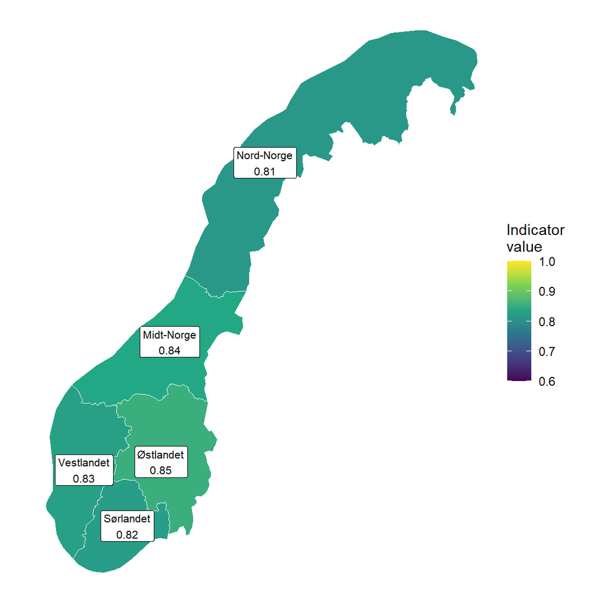

Figure 1: Indicator values per region (provisional)

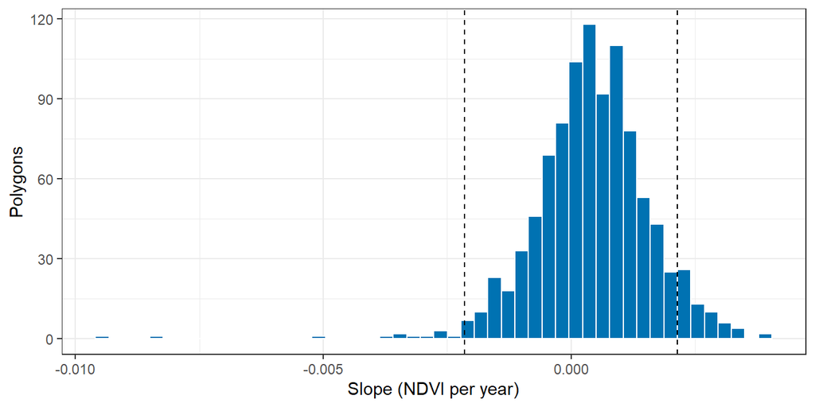

Figure 2: Trend per polygon. Dashed lines: the limit for good condition (0.6) in either direction

68% of the polygons have a positive trend, and 7.7% score below 0.6.

## 11. Export file

```r
# ============================================================
# NO_NDVI_001 - final export stage: platform-format indicator maps +
# Miljødirektoratet delivery tables.
#
# PROVISIONAL INDICATOR. MODIS only (250 m), so only the 983 NiN wetland
# polygons of at least one MODIS pixel with >= 10 growing seasons are
# scored, and no uncertainty is computed (sd = NA throughout). See the
# README's "Status" section.
#
# Reads NO_NDVI_001_trend_scaling.R's results in ../outputs/results/ and
# writes, to ../outputs/deliverables/:
#   NO_NDVI_001_indicatorMap_region.rds    5 landsdeler (primary)
#   NO_NDVI_001_indicatorMap_polygon.rds   every scored NiN wetland polygon
#   NO_NDVI_001_values.csv / .xlsx         region rows + national row,
#                                          metadata sheet, polygon sheet
#   NO_NDVI_001_map.png
#
# Column mapping (platform <- pipeline):
#   v_YYYY          <- slope of the linear trend of peak growing-season NDVI
#                     against year, per polygon (NDVI units per year);
#                     region / national = area-weighted mean over polygons
#   i_YYYY          <- index (two-sided piecewise-linear scaling of |slope|;
#                     region / national = area-weighted mean over polygons,
#                     identical to the pipeline's regional table)
#   sd_YYYY         <- NA (no uncertainty estimated yet)
#   reference_high  <- 0 (no trend = reference condition)
#   reference_low   <- the permutation null distribution's maximum |slope|
#                     (index 0)
#   thr             <- 0.6 on the indicator scale, which by construction is
#                     the 97.5th percentile of the |slope| null distribution
# Supplementary columns kept in csv/xlsx only: n (polygons), mean_abs_slope,
# slope_threshold (the |slope| at thr), i_sd_polygons.
#
# Year label: the trend window's last year (2026; the window is 2000-2026).
# The 2026 growing season was fetched up to July and is therefore partial.
# ============================================================

suppressPackageStartupMessages({ library(sf); library(dplyr); library(readr) })

if (requireNamespace("rstudioapi", quietly = TRUE) && rstudioapi::isAvailable()) {
  setwd(dirname(rstudioapi::getActiveDocumentContext()$path))
} else {
  cmd_args <- commandArgs(trailingOnly = FALSE); fm <- grep("^--file=", cmd_args)
  if (length(fm)) setwd(dirname(normalizePath(sub("^--file=", "", cmd_args[fm]))))
}
source(file.path("..", "..", "Tools", "export_platform_format.R"))

ID      <- "NO_NDVI_001"
VERSION <- Sys.getenv("NDVI001_DELIVERY_VERSION", "000.001")
THR     <- 0.6

res_dir <- file.path("..", "outputs", "results")
out_dir <- file.path("..", "outputs", "deliverables")

region_ids <- c("Nord-Norge" = 1L, "Midt-Norge" = 2L, "Østlandet" = 3L, "Vestlandet" = 4L, "Sørlandet" = 5L)
region_names <- setNames(names(region_ids), region_ids)

# --- inputs -----------------------------------------------------------
anch <- read_csv(file.path(res_dir, "NO_NDVI_001_trend_scaling_anchors.csv"), show_col_types = FALSE)
pol  <- read_csv(file.path(res_dir, "NO_NDVI_001_trend_scaling_polygons.csv"), show_col_types = FALSE) %>%
  mutate(id = as.character(id))
reg_tab <- read_csv(file.path(res_dir, "NO_NDVI_001_trend_scaling_regional.csv"), show_col_types = FALSE)
DATA_YEAR <- as.integer(anch$year_max)
cat("Inputs:", nrow(pol), "polygons,", nrow(reg_tab), "regions; trend window",
    anch$year_min, "-", anch$year_max, "\n")

# Polygon geometry: the same NiN geodatabase the pipeline scored.
gdb <- list.files(file.path("..", "data", "nin_data"), pattern = "\\.gdb$", full.names = TRUE)[1]
if (is.na(gdb)) stop("NiN geodatabase missing - run R/fetch_nin_data.R first.")
nin <- st_read(gdb, layer = "naturtyper_nin_omr", quiet = TRUE) %>%
  rename(geometry = SHAPE) %>% st_set_geometry("geometry") %>%
  filter(identifikasjon_lokalId %in% pol$id) %>%
  transmute(id = as.character(identifikasjon_lokalId), naturtype = naturtype, tilstand = tilstand) %>%
  st_make_valid()
stopifnot(nrow(nin) == nrow(pol))

# Region geometry. regions.shp's `region` text has an encoding fault, so use `id`.
regions <- st_read(file.path("..", "data", "spatial", "regions.shp"), quiet = TRUE) %>%
  transmute(areaId = as.integer(id), area = unname(region_names[as.character(id)]))

pd <- pol %>% filter(!is.na(region))

# --- region (primary) ---------------------------------------------------
reg_stats <- pd %>% group_by(region) %>%
  summarise(v = weighted.mean(slope, area_m2), i = weighted.mean(index, area_m2),
            n = n(), mean_abs_slope = weighted.mean(abs(slope), area_m2),
            i_sd_polygons = sd(index), .groups = "drop")
# Must equal the pipeline's own regional table.
chk <- inner_join(reg_stats, reg_tab, by = "region")
stopifnot(nrow(chk) == nrow(reg_tab), isTRUE(all.equal(chk$i, chk$index)), all(chk$n.x == chk$n.y))

region_long <- regions %>%
  inner_join(reg_stats, by = c("area" = "region")) %>%
  transmute(area, areaId, year = DATA_YEAR, v, sd = NA_real_, i,
            reference_high = 0, reference_low = anch$extreme, thr = THR,
            n, mean_abs_slope, slope_threshold = anch$threshold, i_sd_polygons) %>%
  arrange(areaId)

# --- polygons -------------------------------------------------------------
poly_long <- nin %>%
  inner_join(pol, by = "id") %>%
  transmute(area = region, areaId = id, year = DATA_YEAR,
            v = slope, sd = NA_real_, i = index,
            reference_high = 0, reference_low = anch$extreme, thr = THR,
            n_years = n_years, naturtype, tilstand, area_m2)

# --- national row -----------------------------------------------------------
national <- tibble(
  area = "Norge", areaId = 0L, year = DATA_YEAR,
  v = weighted.mean(pd$slope, pd$area_m2), sd = NA_real_, i = weighted.mean(pd$index, pd$area_m2),
  reference_high = 0, reference_low = anch$extreme, thr = THR,
  n = nrow(pd), mean_abs_slope = weighted.mean(abs(pd$slope), pd$area_m2),
  slope_threshold = anch$threshold, i_sd_polygons = sd(pd$index)
)

# --- metadata sheet ---------------------------------------------------------
metadata <- c(
  "Indicator ID"                 = ID,
  "Version"                      = VERSION,
  "Status"                       = "PROVISIONAL - not finished. MODIS only; Sentinel-2 and Landsat not yet included; no uncertainty estimate. Delivered so the platform pipeline and the method can be reviewed",
  "Indicator name (public)"      = "Primærproduksjon i våtmark (NDVI-trend)",
  "Indicator name (technical)"   = "Wetland primary production - deviation of the long-term trend in peak growing-season NDVI from no trend",
  "Ecosystem"                    = "Våtmark (wetland); IUCN GET TF1.6 Boreal/temperate bogs, TF1.7 Boreal/temperate fens",
  "ECT class"                    = "B2 - Structural State Characteristics or B3 - Functional State Characteristics",
  "Spatial units delivered"      = "landsdel (5 regions, primary map), individual NiN wetland polygons; national value in the values table (area = Norge)",
  "CRS"                          = "EPSG:25833 (ETRS89 / UTM 33N)",
  "Data year label"              = paste0(DATA_YEAR, " - last year of the trend window ", anch$year_min, "-", anch$year_max, ". The ", DATA_YEAR, " growing season was fetched up to July and is partial"),
  "Variable (v)"                 = "Slope (NDVI units per year) of an ordinary least-squares line through each polygon's peak (maximum) growing-season NDVI per year, MODIS MOD13Q1 v6.1 (250 m, 16-day composites, late May to September; value of the pixel at the polygon centroid). Region / national value = area-weighted mean slope over polygons",
  "Indicator (i)"                = "Two-sided piecewise-linear scaling of |slope|: 0 -> 1, threshold -> 0.6, extreme -> 0, clamped at 0. Greening and browning both count as deviation. Aggregated as the area-weighted mean of polygon values",
  "reference_high (X100)"        = "0 - no trend. Reference condition is a stable NDVI over time",
  "reference_low (X0)"           = paste0(signif(anch$extreme, 4), " NDVI/yr (|slope|) - the maximum of a permutation null distribution: each polygon's year labels shuffled once and the slope refitted (n = ", anch$n_null, ")"),
  "Threshold (thr)"              = paste0("0.6 on the indicator scale = |slope| ", signif(anch$threshold, 4), " NDVI/yr, the 97.5th percentile of the same null distribution (column slope_threshold)"),
  "Uncertainty (sd)"             = "Not estimated (NA). Planned as further work",
  "Number of observations"       = paste0(nrow(pd), " NiN wetland polygons scored nationally: at least one MODIS pixel (>= 62,500 m2) and at least ", anch$min_years, " growing seasons. Few in some regions (Sørlandet n = ", sum(pd$region == "Sørlandet"), ")"),
  "Justification of references"  = "Adapted from the trend-based NDVI scaling of NINA's mountain condition assessment (Framstad et al., 2022), since no scaling was defined for the wetland NDVI indicator in the original work",
  "Data sources"                 = "MODIS/Terra Vegetation Indices 16-Day L3 Global 250 m (MOD13Q1 v6.1), NASA LP DAAC, doi:10.5067/MODIS/MOD13Q1.061, via NASA Earthdata (no restrictions on reuse); NiN nature-type dataset, Miljødirektoratet (downloaded 2026-08-05)",
  "Method note"                  = "Reconstruction of the wetland NDVI indicator in NINA's ecosystemCondition documentation (chapter 15), which defined no scaling. The original extracted NDVI with Google Earth Engine scripts; here MODIS is fetched directly from NASA without Earth Engine. The original exploratory analysis is kept in R/NO_NDVI_001_wetland_pipeline.R",
  "Documentation"                = "https://github.com/Chimal93/wetland_condition_indicators/tree/main/NO_NDVI_001 ; original: https://ninanor.github.io/ecosystemCondition/NDVI-indicator-wetland.html",
  "Column spelling note"         = "reference_high / reference_low as in the platform's example file; the platform docs and the contract text spell them referance_*",
  "Produced by"                  = "Sállir Natur AS",
  "Generated"                    = format(Sys.time(), "%Y-%m-%d %H:%M")
)

export_platform_indicator(
  id       = ID,
  units    = list(region = region_long, polygon = poly_long),
  national = national,
  metadata = metadata,
  out_dir  = out_dir,
  png_title = "NO_NDVI_001 - Primærproduksjon i våtmark (NDVI-trend, foreløpig)"
)
```

## 12. Author contributions

**CRediT statement**

- Software (code development): JACB, LK
- Validation (assessment): JACB, LK
- Writing of the project report: BS, JACB

BS: Bendik Sivertsen. JACB: Jesus Adrian Chimal-Ballesteros. LK: Lasse Keetz.

AI tools: Claude (Anthropic) was used for code development and review, for running and checking analyses, and for drafting this document. The use is described in the repository README.

**TipSession Info**